# Mini Project 1

Richa Singh

September 6, 2018

## Question 1

a)Use the density function to analytically compute the probability that the lifetime of the satellite exceeds 15 years.

```r
a <- 1 - (2*pexp(q=15,rate=0.1,lower.tail = TRUE, log.p = FALSE) - pexp(q=15, rate = 0.2, lower.tail = TRUE, log.p = FALSE))
a
```

```
## [1] 0.3964733
```

b)i)Simulate one draw of the block lifetimes XA and XB. Use these draws to simulate one draw of the satellite lifetime T.

```r
xa <- 2*rexp(1,0.1)
xb <- rexp(1,0.2)
t <- 2*rexp(1,0.1) - rexp(1,0.2)
t
```

```
## [1] 52.99131
```

Bonus point

```r
print(paste("Probability that the lifetime of the satellite exceeds 15 years and simulate one draw of the block lifetimes of XA, XB and T are",round(a,digits = 3),",",round(xa,digits = 3),",",round(xb,digits = 3),",",round(t,digits = 3)))
```

```
## [1] "Probability that the lifetime of the satellite exceeds 15 years and simulate one draw of the block lifetimes of XA, XB and T are 0.396 , 22.27 , 1.142 , 52.991"
```

ii)Repeat the previous step 10,000 times

```r
p.10k <- replicate(10000,(2*rexp(1,0.1) - rexp(1,0.2)))
```

iii)Make a histogram of the draws of T using ???hist??? function. Superimpose the density function given above.

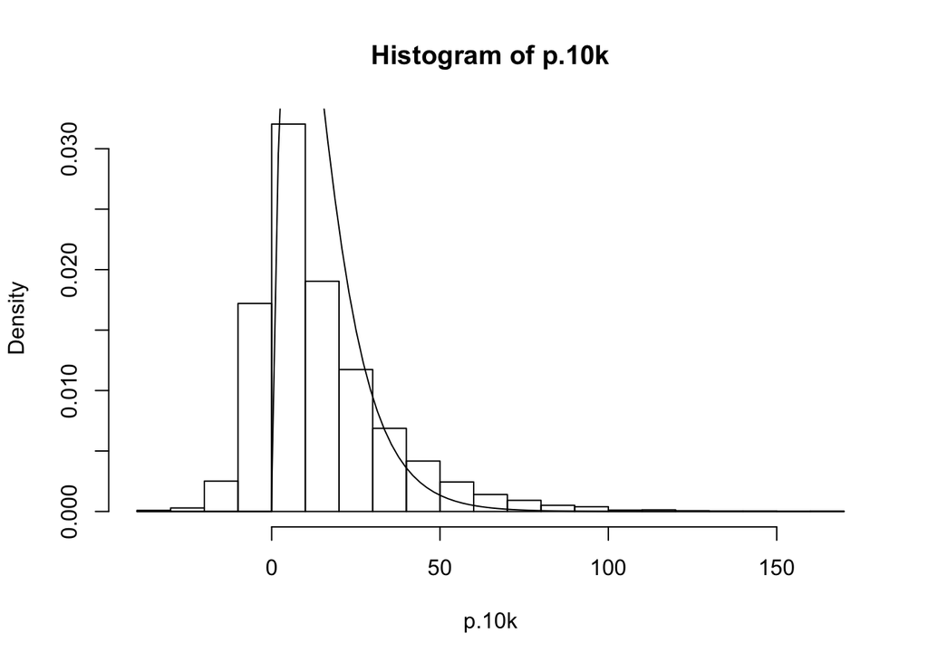

```r
hist(p.10k, probability = T)
curve((2*dexp(x,rate = 0.1)-dexp(x,rate = 0.2)), add = T, xlab = "x", ylab = "density")
```

iv)Use the saved draws to estimate E(T).

```r
mean(p.10k)
```

```
## [1] 14.5673
```

v)Use the saved draws to estimate the probability that the satellite lasts more than 15 years.Compare with the exact answer computed in part (a).

```r
mean(p.10k > 15)
```

```
## [1] 0.3718
```

vi)Repeat the above process of obtaining an estimate of E(T) and an estimate of the probability four more times

E(p.10k) and P(p.10k >15) comes out ot be the same for the next four steps.

```r
mean10k <- replicate(4,mean(p.10k))
prob10k <- replicate(4, mean(p.10k > 15))
mean10k
```

```
## [1] 14.5673 14.5673 14.5673 14.5673
```

```r
prob10k
```

```
## [1] 0.3718 0.3718 0.3718 0.3718
```

c)Repeat part (vi) five times using 1,000 and 100,000 Monte Carlo replications instead of 10,000.Make a table of results. Comment on what you see and provide an explanation

```r
p.1k <- replicate(1000,(2*rexp(1,0.1) - rexp(1,0.2)))
p.100k <- replicate(100000,(2*rexp(1,0.1) - rexp(1,0.2)))

mean1k<- replicate(5,mean(p.1k))
prob1k <- replicate(5, mean(p.1k > 15))
mean1k
```

```
## [1] 14.57414 14.57414 14.57414 14.57414 14.57414
```

```r
prob1k
```

```
## [1] 0.378 0.378 0.378 0.378 0.378
```

```r
mean100k<- replicate(5,mean(p.100k))
prob100k <- replicate(5, mean(p.100k > 15))
mean100k
```

```
## [1] 15.06008 15.06008 15.06008 15.06008 15.06008
```

```r
prob100k
```

```
## [1] 0.37905 0.37905 0.37905 0.37905 0.37905
```

```r
table.data <- rbind(
  cbind(mean(p.1k), mean(p.10k), mean(p.100k)),
  cbind(mean(mean1k),mean(mean10k),mean(mean100k)),
  cbind(mean(prob1k), mean(prob10k), mean(prob100k))
)

rownames(table.data) <- c('mean of simulations','estimate of E(T) i.e mean of mean','estimate of the Probability of P(x>15)')
colnames(table.data) <- c('for 1k simulations','for 10k simulations','for 100k simulations')

table.data
```

```
##                                        for 1k simulations
## mean of simulations                              14.57414
## estimate of E(T) i.e mean of mean                14.57414
## estimate of the Probability of P(x>15)            0.37800
##                                        for 10k simulations
## mean of simulations                                14.5673
## estimate of E(T) i.e mean of mean                  14.5673
## estimate of the Probability of P(x>15)              0.3718
##                                        for 100k simulations
## mean of simulations                                15.06008
## estimate of E(T) i.e mean of mean                  15.06008
## estimate of the Probability of P(x>15)              0.37905
```

From the results, we can see that the real mean estimated was 15. When we do n number of simulations to find the Monte carlo estimate of the mean as we increase the n i.e the number of simulations, by law of large numbers the result tends to approximate the real mean.

## Question 2

Use a Monte Carlo approach estimate the value of pi based on 10,000 replications.

The area of the circle would be pi * r^2 where r is 0.5. The area of the square is s2 where s is 1.Therefore the ratio of the area of the circle to the area of the square would be pi/4. Now,suppose we generate random points to fall uniformly in the area of the square (x varies from 0 to 1 and y varies from 0 to 1). We can state ratio of the number of points falling inside the circle to the total number of the points is equal to the ratio of the area of the circle to the area of the square. * `pi/4 = (number of points in the circle)/(total number of points)`

Therefore,pi can be defined by the equation. pi = 4 * (number of points in the circle)/(total number of points) .Generate a process that would generate random numbers between 0 and 1 for x and y positions of 10000 points and count how many points fall with the circle, then determine an estimated version of pi

```r
montecarloPi <- function(trials) {
  count = 0
  for(i in 1:trials) {
    if((runif(1,-0.5,0.5)^2 + runif(1,-0.5,0.5)^2)< (0.5^2)) {
      count = count + 1
    }
  }
  return((count*4)/trials)
}

montecarloPi(10000)
```

```
## [1] 3.1432
```